# Analysis of Bikeshare Data with chatGPT

# Introduction

The purpose of this analysis is to use chatGPT as an assistant to produce a predictive model for the bikeshare dataset. First we will import the Bikeshare dataset into R as well as load packages for analysis.

```r
library(tidyverse)
library(car)
library(boot)
library(here)
library(knitr)
library(glmnet)
data <- read_csv(here("inputs\\day.csv"))
```

# Data Exploration

We can do some preliminary analysis of the data to see if particular models may be more appropriate then others.

| instant | dteday | season | yr | mnth | holiday | weekday | workingday | weathersit | temp | atemp | hum | windspeed | casual | registered | cnt |
| --- | --- | --- | --- | --- | --- | --- | --- | --- | --- | --- | --- | --- | --- | --- | --- |
| 1 | 2011-01-01 | 1 | 0 | 1 | 0 | 6 | 0 | 2 | 0.344167 | 0.363625 | 0.805833 | 0.1604460 | 331 | 654 | 985 |
| 2 | 2011-01-02 | 1 | 0 | 1 | 0 | 0 | 0 | 2 | 0.363478 | 0.353739 | 0.696087 | 0.2485390 | 131 | 670 | 801 |
| 3 | 2011-01-03 | 1 | 0 | 1 | 0 | 1 | 1 | 1 | 0.196364 | 0.189405 | 0.437273 | 0.2483090 | 120 | 1229 | 1349 |
| 4 | 2011-01-04 | 1 | 0 | 1 | 0 | 2 | 1 | 1 | 0.200000 | 0.212122 | 0.590435 | 0.1602960 | 108 | 1454 | 1562 |
| 5 | 2011-01-05 | 1 | 0 | 1 | 0 | 3 | 1 | 1 | 0.226957 | 0.229270 | 0.436957 | 0.1869000 | 82 | 1518 | 1600 |
| 6 | 2011-01-06 | 1 | 0 | 1 | 0 | 4 | 1 | 1 | 0.204348 | 0.233209 | 0.518261 | 0.0895652 | 88 | 1518 | 1606 |

We have some categorical variables in weathersit, which has 4 factors based on worsening weather conditions from clear, to mist, to light snow/rain, to heavy snow/rain. And we have a season variable indicating the 4 different seasons.

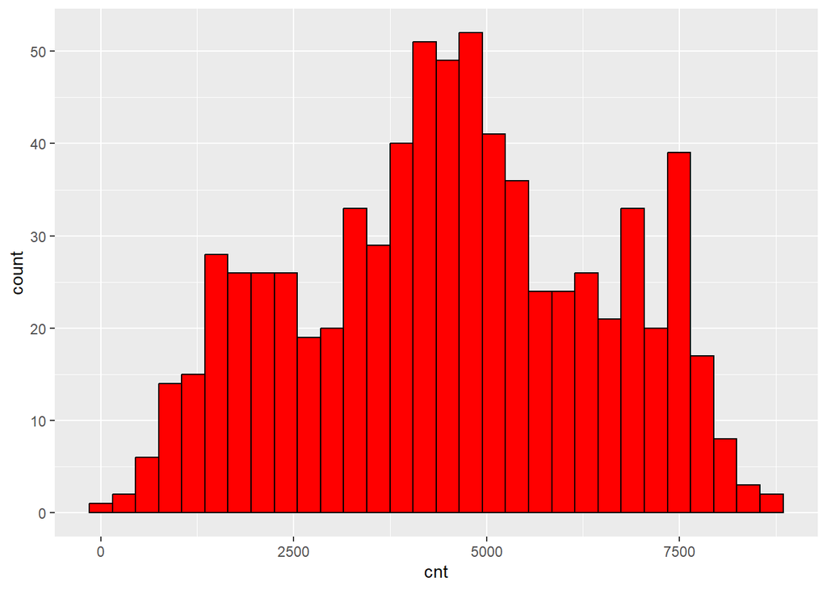

```r
data %>%
  ggplot(aes(x = cnt)) + geom_histogram(fill = "red", color = "black")
```

The response in this case is a count of bicycles rented for the day. Count data is most often represented by a poisson or negative/positive binomial distribution. The difference between these 2 distributions is that poisson regression is used for count where the mean is roughly equal to the standard deviation. We check to see whether this holds for the bikeshare data.

```r
data$cnt %>% sd()
```

```
## [1] 1937.211
```

```r
data$cnt %>% mean()
```

```
## [1] 4504.349
```

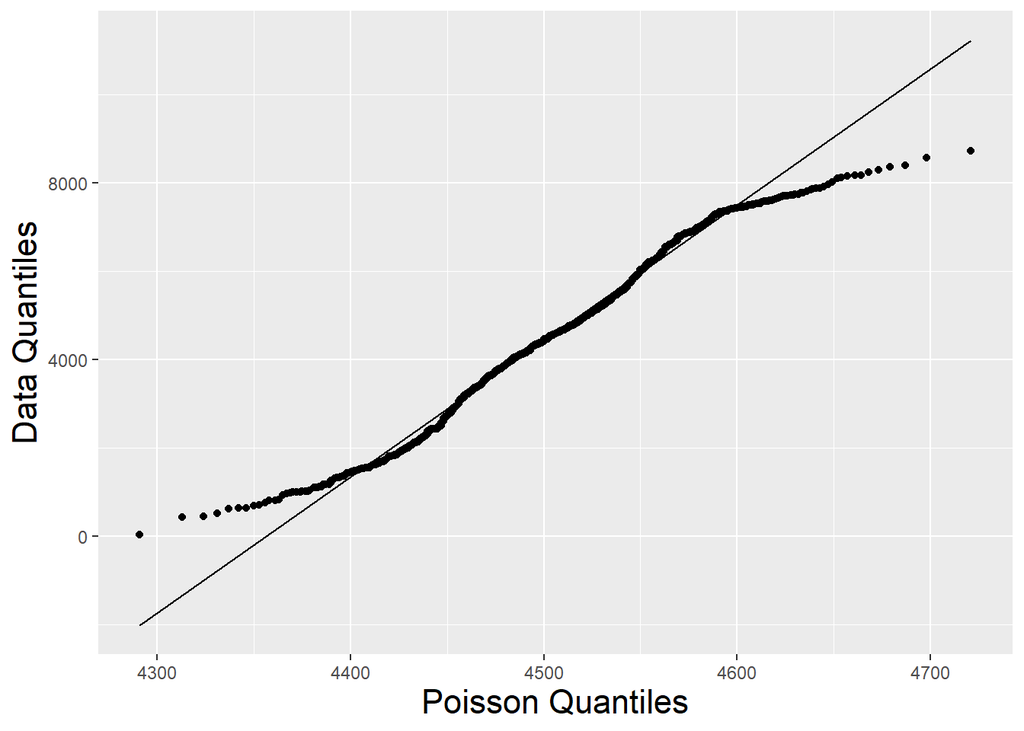

```r
data %>%
  ggplot(aes(sample = cnt))+stat_qq(distribution = stats::qpois, dparams = list(lambda = mean(data$cnt)))+ stat_qq_line(distribution = stats::qpois, dparams = list(lambda = mean(data$cnt))) +
  ylab("Data Quantiles") +
  xlab("Poisson Quantiles") +
  theme(axis.title.y = element_text(size = rel(1.5), angle = 90)) +
  theme(axis.title.x = element_text(size = rel(1.5), angle = 00))
```

Now lets look at how some of our predictors relate to the number of bikes rented.

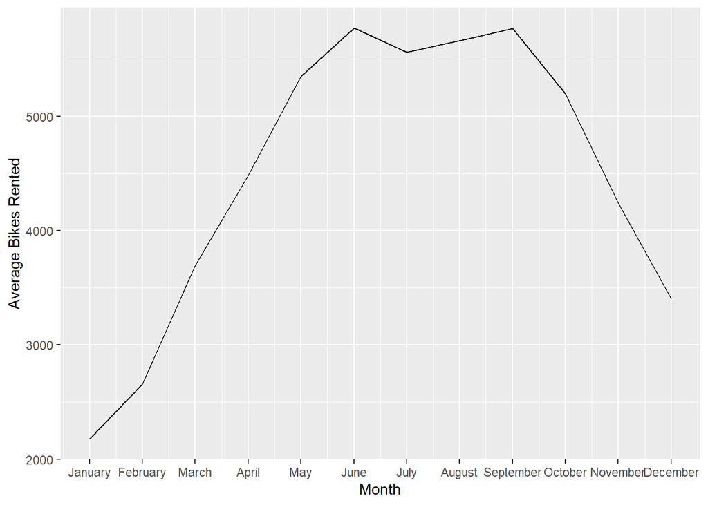

```r
data %>%
  group_by(mnth) %>%
  summarize(counts = mean(cnt)) %>%
  ungroup() %>%
  ggplot(aes(x = mnth, y = counts))+geom_line() +
  xlab("Month") +
  ylab("Average Bikes Rented") +
  scale_x_continuous(breaks = 1:12, labels = month.name)
```

As we may expect bike rentals peak in the warmer summer months and decline during colder winter months before picking back up again as the seasons change. It will be important we capture the cyclical nature of this strong predictor for the bike rentals in our model.

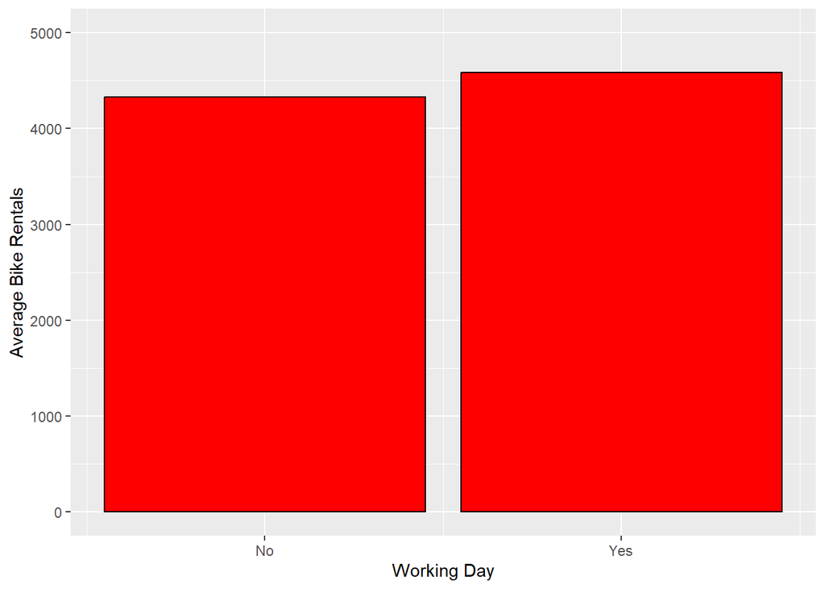

```r
data %>%
  select(cnt, workingday) %>%
  group_by(workingday) %>%
  summarize(counts = mean(cnt)) %>%
  ungroup() %>%
  ggplot(aes(x = workingday, y = counts))+geom_bar(stat = "identity",
                                                   fill = "red", color = "black") +
  ylab("Average Bike Rentals") +
  xlab("Working Day") +
  scale_y_continuous(limits = c(0,5000)) +
  scale_x_continuous(breaks = c(0,1), labels = c("No", "Yes"))
```

We see little difference in the average rentals on working days as non working days. This suggests that this predictor will not be a strong indicator in our model for predicting the number of bikes rented.

# Model Building

First we can try a basic 80/20 validation and test split and fit the full poisson regression model. We make slight adjustments to the features to ensure dates are encoded as datetime objects and remove variables like instant which just refer to the observation number, we also remove registered and casual since these variables are just leakage of the counts into the predictors. Then compute the mean absolute and mean square errors on the test data.

```r
# Convert date to Date type
data$date <- as.Date(data$dteday)

# Remove unnecessary columns
data <- data %>% dplyr::select(-instant, -dteday, -casual, -registered)
```

```r
# Split the data into training and testing sets
set.seed(1)
train_indices <- sample(1:nrow(data), size = 0.8 * nrow(data))
train_data <- data[train_indices,]
test_data <- data[-train_indices,]

# Fit Poisson regression model
model <- glm(cnt ~ ., data = train_data, family = poisson())
summary(model)
```

```
##
## Call:
## glm(formula = cnt ~ ., family = poisson(), data = train_data)
##
## Deviance Residuals:
##     Min       1Q   Median       3Q      Max
## -85.659   -8.648    0.412    9.188   46.235
##
## Coefficients:
##               Estimate Std. Error z value Pr(>|z|)
## (Intercept) 50.5191625  1.0722696   47.11   <2e-16 ***
## season       0.1325396  0.0013149  100.80   <2e-16 ***
## yr           1.5259023  0.0262215   58.19   <2e-16 ***
## mnth         0.0769824  0.0021782   35.34   <2e-16 ***
## holiday     -0.1468259  0.0040773  -36.01   <2e-16 ***
## weekday      0.0144493  0.0003096   46.67   <2e-16 ***
## workingday   0.0285974  0.0013797   20.73   <2e-16 ***
## weathersit  -0.1587241  0.0015740 -100.84   <2e-16 ***
## temp         0.3412560  0.0236376   14.44   <2e-16 ***
## atemp        0.9497779  0.0269530   35.24   <2e-16 ***
## hum         -0.1531685  0.0062171  -24.64   <2e-16 ***
## windspeed   -0.5218447  0.0088681  -58.84   <2e-16 ***
## date        -0.0028714  0.0000717  -40.05   <2e-16 ***
## ---
## Signif. codes:  0 '***' 0.001 '**' 0.01 '*' 0.05 '.' 0.1 ' ' 1
##
## (Dispersion parameter for poisson family taken to be 1)
##
##     Null deviance: 526589  on 583  degrees of freedom
## Residual deviance: 130851  on 571  degrees of freedom
## AIC: 136791
##
## Number of Fisher Scoring iterations: 4
```

```r
# Make predictions
test_data$pred_count <- predict(model, newdata = test_data, type = "response")

# Calculate mean absolute error (MAE)
mae <- mean(abs(test_data$cnt - test_data$pred_count))
cat("Mean Absolute Error (MAE):", mae, "\n")
```

```
## Mean Absolute Error (MAE): 745.6326
```

```r
# Calculate root mean squared error (RMSE)
rmse <- sqrt(mean((test_data$cnt - test_data$pred_count)^2))
cat("Root Mean Squared Error (RMSE):", rmse, "\n")
```

```
## Root Mean Squared Error (RMSE): 983.0236
```

Next we will do some additional feature engineering. We will encode the datetime as a cyclical variable using sine and cosine functions. This will establish that for instance January is closer to December then it is to April.

```r
train_data$mnth_sin <- sin(2 * pi * train_data$mnth / 12)
train_data$mnth_cos <- cos(2 * pi * train_data$mnth / 12)

train_data$weekday_sin <- sin(2 * pi * train_data$weekday / 7)
train_data$weekday_cos <- cos(2 * pi * train_data$weekday / 7)

test_data$mnth_sin <- sin(2 * pi * test_data$mnth / 12)
test_data$mnth_cos <- cos(2 * pi * test_data$mnth / 12)

test_data$weekday_sin <- sin(2 * pi * test_data$weekday / 7)
test_data$weekday_cos <- cos(2 * pi * test_data$weekday / 7)

data$mnth_sin <- sin(2 * pi * data$mnth / 12)
data$mnth_cos <- cos(2 * pi * data$mnth / 12)

data$weekday_sin <- sin(2 * pi * data$weekday / 7)
data$weekday_cos <- cos(2 * pi * data$weekday / 7)
```

```r
# Fit Poisson regression model
model <- glm(cnt ~ . + weathersit*temp, data = train_data, family = poisson())
summary(model)
```

```
##
## Call:
## glm(formula = cnt ~ . + weathersit * temp, family = poisson(),
##     data = train_data)
##
## Deviance Residuals:
##     Min       1Q   Median       3Q      Max
## -81.798   -8.470    0.386    9.127   45.780
##
## Coefficients:
##                   Estimate Std. Error z value Pr(>|z|)
## (Intercept)      4.313e+01  1.080e+00  39.938  < 2e-16 ***
## season           1.594e-01  1.367e-03 116.580  < 2e-16 ***
## yr               1.341e+00  2.642e-02  50.733  < 2e-16 ***
## mnth             8.045e-02  2.197e-03  36.616  < 2e-16 ***
## holiday         -1.348e-01  4.308e-03 -31.284  < 2e-16 ***
## weekday          1.956e-02  5.402e-04  36.207  < 2e-16 ***
## workingday       2.889e-02  2.283e-03  12.651  < 2e-16 ***
## weathersit      -4.267e-01  4.404e-03 -96.890  < 2e-16 ***
## temp            -2.477e-01  2.704e-02  -9.161  < 2e-16 ***
## atemp            6.523e-01  2.689e-02  24.257  < 2e-16 ***
## hum             -9.542e-02  6.368e-03 -14.984  < 2e-16 ***
## windspeed       -5.466e-01  8.936e-03 -61.168  < 2e-16 ***
## date            -2.362e-03  7.224e-05 -32.701  < 2e-16 ***
## mnth_sin         1.109e-01  1.845e-03  60.104  < 2e-16 ***
## mnth_cos        -1.082e-01  1.977e-03 -54.710  < 2e-16 ***
## weekday_sin      1.809e-02  1.505e-03  12.019  < 2e-16 ***
## weekday_cos      5.572e-03  1.479e-03   3.767 0.000165 ***
## weathersit:temp  5.018e-01  7.856e-03  63.882  < 2e-16 ***
## ---
## Signif. codes:  0 '***' 0.001 '**' 0.01 '*' 0.05 '.' 0.1 ' ' 1
##
## (Dispersion parameter for poisson family taken to be 1)
##
##     Null deviance: 526589  on 583  degrees of freedom
## Residual deviance: 116912  on 566  degrees of freedom
## AIC: 122862
##
## Number of Fisher Scoring iterations: 4
```

```r
# Make predictions
test_data$pred_count <- predict(model, newdata = test_data, type = "response")

# Calculate mean absolute error (MAE)
mae <- mean(abs(test_data$cnt - test_data$pred_count))
cat("Mean Absolute Error (MAE):", mae, "\n")
```

```
## Mean Absolute Error (MAE): 716.2335
```

```r
# Calculate root mean squared error (RMSE)
rmse <- sqrt(mean((test_data$cnt - test_data$pred_count)^2))
cat("Root Mean Squared Error (RMSE):", rmse, "\n")
```

```
## Root Mean Squared Error (RMSE): 950.1785
```

We get a slight decrease in both the absolute and square error in the test. We can now test create some additional features with the model through the residual plots.

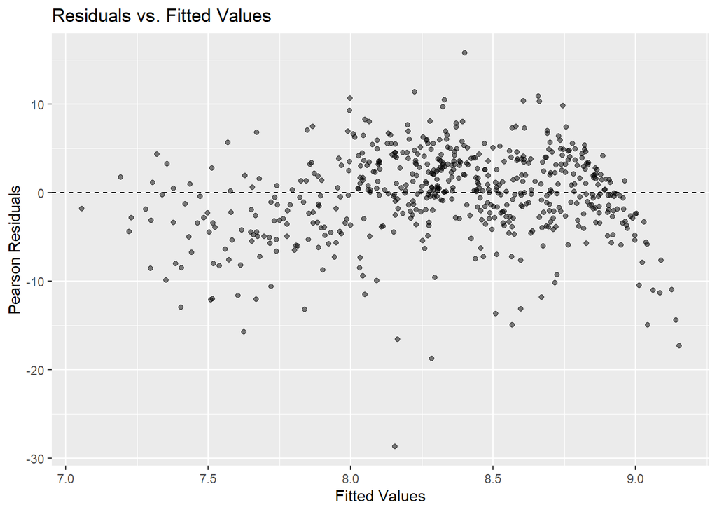

```r
# Creating a dataframe containing residuals and fitted values
df <- broom::augment(model)

# Residuals vs. fitted values plot
ggplot(df, aes(x = .fitted, y = .resid/sqrt(.fitted))) +
  geom_point(alpha = 0.5) +
  geom_hline(yintercept = 0, linetype = "dashed") +
  labs(title = "Residuals vs. Fitted Values", x = "Fitted Values", y = "Pearson Residuals")
```

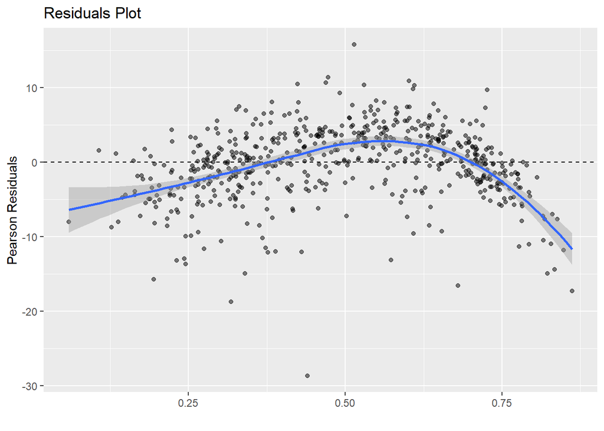

```r
# Residuals vs. continuous predictors
resid.check <- function(data, mapping) {
  ggplot(data, mapping) +
    geom_point(alpha = 0.5) +
    geom_hline(yintercept = 0, linetype = "dashed") +
    labs(title = "Residuals Plot", x = "", y = "Pearson Residuals") +
    geom_smooth()
}
resid.check(df, aes(x = temp, y = .resid/sqrt(.fitted)))
```

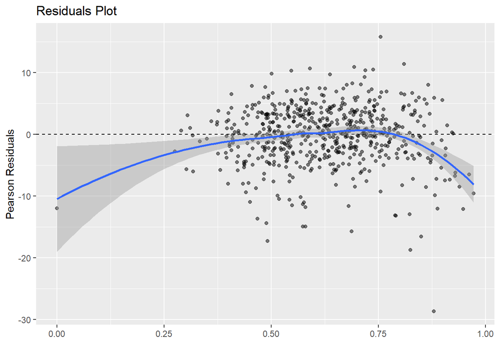

```r
resid.check(df, aes(x = hum, y = .resid/sqrt(.fitted)))
```

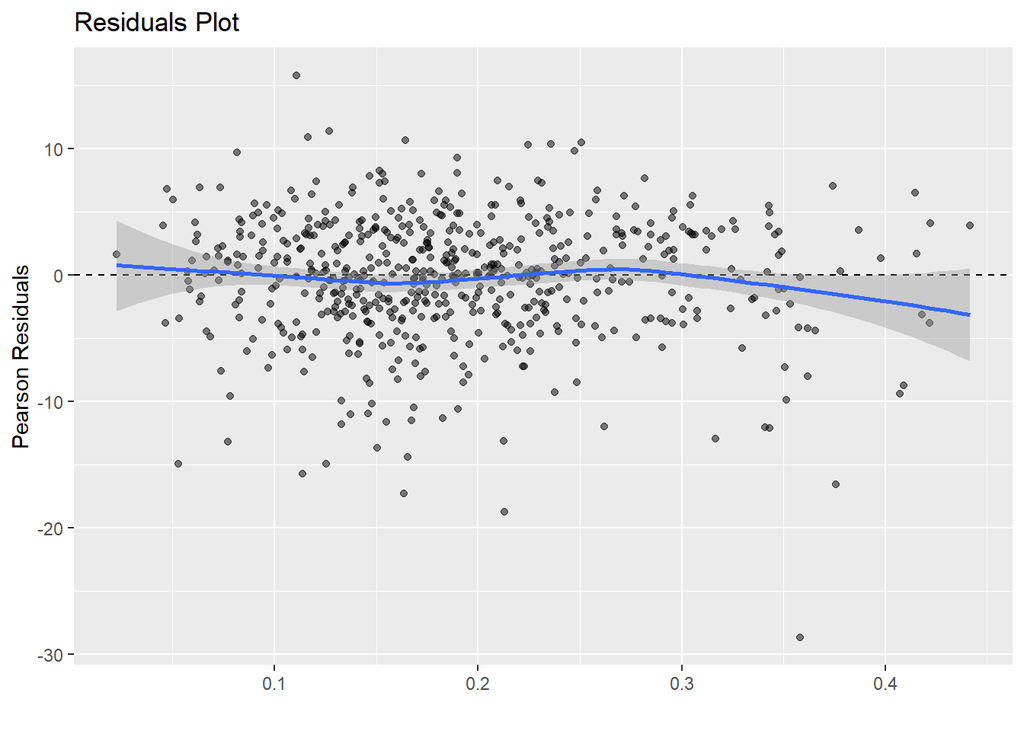

```r
resid.check(df, aes(x = windspeed, y = .resid/sqrt(.fitted)))
```

We check our continuous predictors and find a definite pattern within the temp predictor, suggesting there is a relationship not being captured by the model. We can adjust for this by adding transformations of temp.

```r
# Fit Poisson regression model
model <- glm(cnt ~ . - temp + weathersit*temp + poly(temp,3), data = train_data, family = poisson())
summary(model)
```

```
##
## Call:
## glm(formula = cnt ~ . - temp + weathersit * temp + poly(temp,
##     3), family = poisson(), data = train_data)
##
## Deviance Residuals:
##     Min       1Q   Median       3Q      Max
## -82.768   -5.825    0.593    6.303   36.718
##
## Coefficients: (1 not defined because of singularities)
##                   Estimate Std. Error  z value Pr(>|z|)
## (Intercept)      5.011e+01  1.091e+00   45.928  < 2e-16 ***
## season           1.432e-01  1.421e-03  100.764  < 2e-16 ***
## yr               1.488e+00  2.670e-02   55.729  < 2e-16 ***
## mnth             8.578e-02  2.215e-03   38.721  < 2e-16 ***
## holiday         -9.715e-02  4.309e-03  -22.548  < 2e-16 ***
## weekday          1.828e-02  5.401e-04   33.850  < 2e-16 ***
## workingday       2.383e-02  2.288e-03   10.414  < 2e-16 ***
## weathersit      -2.106e-01  4.700e-03  -44.799  < 2e-16 ***
## atemp            1.464e-01  2.581e-02    5.672 1.41e-08 ***
## hum             -4.293e-01  6.536e-03  -65.682  < 2e-16 ***
## windspeed       -7.163e-01  8.926e-03  -80.250  < 2e-16 ***
## date            -2.835e-03  7.299e-05  -38.844  < 2e-16 ***
## mnth_sin         6.441e-02  1.979e-03   32.548  < 2e-16 ***
## mnth_cos        -5.109e-02  1.993e-03  -25.634  < 2e-16 ***
## weekday_sin      1.189e-02  1.511e-03    7.873 3.47e-15 ***
## weekday_cos      1.156e-02  1.480e-03    7.811 5.65e-15 ***
## temp             1.069e+00  2.663e-02   40.126  < 2e-16 ***
## poly(temp, 3)1          NA         NA       NA       NA
## poly(temp, 3)2  -3.290e+00  2.054e-02 -160.140  < 2e-16 ***
## poly(temp, 3)3  -9.383e-01  2.003e-02  -46.850  < 2e-16 ***
## weathersit:temp  1.011e-01  8.450e-03   11.960  < 2e-16 ***
## ---
## Signif. codes:  0 '***' 0.001 '**' 0.01 '*' 0.05 '.' 0.1 ' ' 1
##
## (Dispersion parameter for poisson family taken to be 1)
##
##     Null deviance: 526589  on 583  degrees of freedom
## Residual deviance:  74756  on 564  degrees of freedom
## AIC: 80710
##
## Number of Fisher Scoring iterations: 4
```

```r
# Make predictions
test_data$pred_count <- predict(model, newdata = test_data, type = "response")

# Calculate mean absolute error (MAE)
mae <- mean(abs(test_data$cnt - test_data$pred_count))
cat("Mean Absolute Error (MAE):", mae, "\n")
```

```
## Mean Absolute Error (MAE): 507.2227
```

```r
# Calculate root mean squared error (RMSE)
rmse <- sqrt(mean((test_data$cnt - test_data$pred_count)^2))
cat("Root Mean Squared Error (RMSE):", rmse, "\n")
```

```
## Root Mean Squared Error (RMSE): 660.9207
```

We see another reduction in error on the test set. We can check the residual plots again.

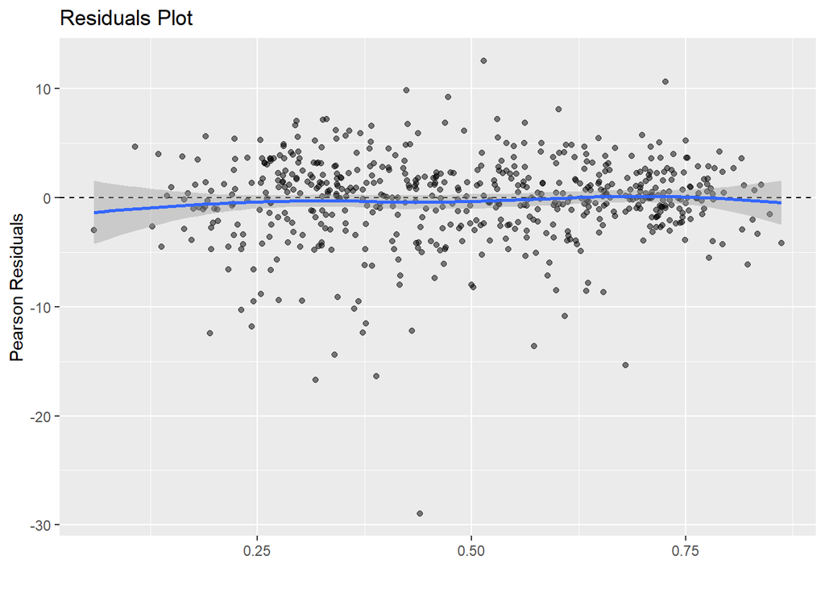

```r
df <- broom::augment(model)
resid.check(df, aes(x = temp, y = .resid/sqrt(.fitted)))
```

Now we get a much more randomly scattered plot of the residuals after the transformation. We can add these additional predictors directly into the dataset

```r
train_data <- train_data %>% dplyr::mutate(temp_2 = temp^2, temp_3 = temp^3)
test_data <- test_data %>% dplyr::mutate(temp_2 = temp^2, temp_3 = temp^3)
```

We may try lasso regression as a method for variable selection.

```r
# Splitting train and test sets for glmnet()
set.seed(1)
test_data <- test_data %>% dplyr::select(-pred_count)
X <- model.matrix(cnt ~ . -1, data = train_data)
X.test <- model.matrix(cnt ~ . -1, data = test_data)
Y <- train_data$cnt
Y.test <- test_data$cnt
# Fit LASSO model
lasso <- glmnet(X, Y, family = "poisson" , alpha = 1)
# Cross Validating lambda values
lasso.cv <- cv.glmnet(X, Y, family = "poisson", alpha = 1)
# Finding optimal lambda
optimal <- lasso.cv$lambda.min
# Fit the optimal lambda model
lasso.mod <- glmnet(X, Y, family = "poisson", alpha = 1, lambda = optimal)

# Make predictions
lasso.pred <- predict(lasso, optimal, newx = X.test)

sqrt(mean((lasso.pred-Y.test)^2))
```

```
## [1] 4838.629
```

We see a rather large increase in RMSE in this case, suggesting that our original model is not overfitting, however we can check this via cross-validation.

```r
set.seed(1)

# Fit poisson regression model
model <- glm(cnt ~ .  + weathersit*temp, data = train_data, family = poisson())

# Initialize a vector to store 10 fold CV errors
cv.error.10 <- rep(0,10)

# Perform 10-fold CV and store errors
for (i in 1:10) {
  glm.fit <- glm(cnt ~ .  + weathersit*temp, data = data,
                 family = poisson())
  cv.error.10[i] <- cv.glm(data, glm.fit, K = 10)$delta[1]
}

cat("Root Mean Squared Error (RMSE) for 10-fold CV:", sqrt(mean(cv.error.10)), "\n")
```

```
## Root Mean Squared Error (RMSE) for 10-fold CV: 966.3007
```

```r
# Compute LOOCV
cv.err <- cv.glm(data, glm.fit)
cat("Root Mean Squared Error (RMSE) for LOOCV:", sqrt(cv.err$delta[1]), "\n")
```

```
## Root Mean Squared Error (RMSE) for LOOCV: 963.5958
```

```r
# Retrain model using the full data

final.mod <- glm(cnt ~ .  + weathersit*temp, data = data, family = poisson())
summary(final.mod)
```

```
##
## Call:
## glm(formula = cnt ~ . + weathersit * temp, family = poisson(),
##     data = data)
##
## Deviance Residuals:
##     Min       1Q   Median       3Q      Max
## -82.843   -8.372    0.971    9.072   47.185
##
## Coefficients:
##                   Estimate Std. Error  z value Pr(>|z|)
## (Intercept)      3.594e+01  9.504e-01   37.817  < 2e-16 ***
## season           1.575e-01  1.185e-03  132.950  < 2e-16 ***
## yr               1.162e+00  2.330e-02   49.892  < 2e-16 ***
## mnth             6.529e-02  1.941e-03   33.627  < 2e-16 ***
## holiday         -1.254e-01  3.948e-03  -31.773  < 2e-16 ***
## weekday          1.810e-02  4.803e-04   37.688  < 2e-16 ***
## workingday       3.527e-02  2.097e-03   16.822  < 2e-16 ***
## weathersit      -4.629e-01  3.910e-03 -118.377  < 2e-16 ***
## temp            -6.471e-01  2.637e-02  -24.540  < 2e-16 ***
## atemp            9.115e-01  2.683e-02   33.973  < 2e-16 ***
## hum             -7.465e-02  5.744e-03  -12.995  < 2e-16 ***
## windspeed       -5.315e-01  8.171e-03  -65.045  < 2e-16 ***
## date            -1.877e-03  6.358e-05  -29.526  < 2e-16 ***
## mnth_sin         8.305e-02  1.658e-03   50.088  < 2e-16 ***
## mnth_cos        -1.237e-01  1.814e-03  -68.216  < 2e-16 ***
## weekday_sin      9.001e-03  1.339e-03    6.724 1.77e-11 ***
## weekday_cos      8.865e-03  1.344e-03    6.597 4.20e-11 ***
## weathersit:temp  5.680e-01  6.960e-03   81.612  < 2e-16 ***
## ---
## Signif. codes:  0 '***' 0.001 '**' 0.01 '*' 0.05 '.' 0.1 ' ' 1
##
## (Dispersion parameter for poisson family taken to be 1)
##
##     Null deviance: 668801  on 730  degrees of freedom
## Residual deviance: 146268  on 713  degrees of freedom
## AIC: 153703
##
## Number of Fisher Scoring iterations: 4
```